# 05 – Linking Microbiome to Metadata: ABX (TAPI) in Patients Without Cancer

Hossaena Ayele, MS

2026-01-12

# Goal for this section

In this notebook, we link microbiome composition to **clinical metadata**.

We focus on the ADM Material from patients without cancer and ask whether receiving a **Triple Antibiotic Pocket Irrigant (TAPI)**—labeled as `ABX` in this dataset—is associated with:

1. Differences in overall community composition *beta diversity)
2. Differences in within-sample diversity (alpha diversity)
3. Changes in the abundance of specific taxa (differential abundance)

> **Tip for Posit Cloud:** Run each code chunk in order using the green “Run” button.

## Step 1 — Load the phyloseq object

This notebook assumes you have already created a `phyloseq_object` in **Notebook 01** for our workshop data.

## Step 2 — Define the comparison and subset the dataset

Our biological question is:

**Among patients without cancer, does receiving TAPI (ABX = Yes vs No) alter the microbiome?**

To answer this cleanly, we will: 1. Restrict to patients without cancer (`CancerSideSample == "No"`) 2. Remove samples with missing ABX information 3. Drop taxa that are no longer present after subsetting

```r
# Subset to patients without cancer
ps_nocancer <- subset_samples(phyloseq_object, CancerSideSample == "No")
ps_nocancer_adm <- subset_samples(ps_nocancer, Material == "ADM")

# Remove samples with missing ABX status
ps_nocancer_adm <- subset_samples(ps_nocancer_adm, !is.na(ABX))

# Drop taxa with zero counts after subsetting
ps_nocancer_adm <- prune_taxa(taxa_sums(ps_nocancer_adm) > 0, ps_nocancer_adm)

ps_nocancer_adm
```

```
## phyloseq-class experiment-level object
## otu_table()   OTU Table:         [ 304 taxa and 16 samples ]
## sample_data() Sample Data:       [ 16 samples by 11 sample variables ]
## tax_table()   Taxonomy Table:    [ 304 taxa by 6 taxonomic ranks ]
```

Before we proceed, it is good practice to confirm the groups we are comparing.

```r
table(sample_data(ps_nocancer_adm)$ABX, useNA = "ifany")
```

```
##
##  No Yes
##   8   8
```

## Step 3 — Beta diversity: does ABX shift community composition?

Community-level comparisons ask whether samples cluster differently as a whole.

We will: 1. Visualize beta diversity using PCoA (Bray–Curtis) 2. Test group differences using PERMANOVA (adonis2) 3. Check a key assumption using betadisper (dispersion / variance)

### Step 3A — PCoA visualization (Bray–Curtis)

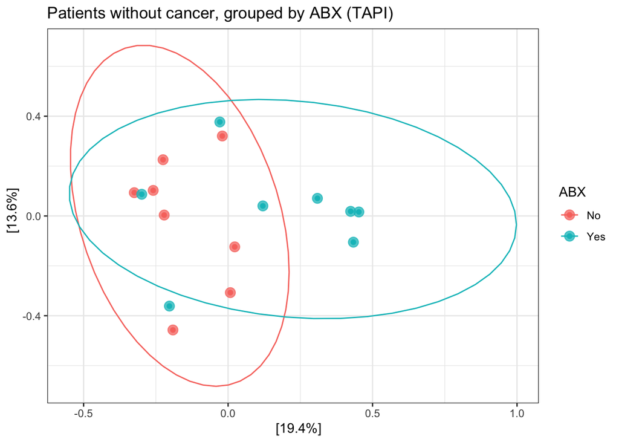

```r
# Ordination using Bray–Curtis
ord_bray <- ordinate(ps_nocancer_adm, method = "PCoA", distance = "bray")

# PCoA plot colored by ABX
p_pcoa_abx <- plot_ordination(ps_nocancer_adm, ord_bray, type = "samples", color = "ABX") +
  geom_point(size = 3.5, alpha = 0.75) +
  stat_ellipse() +
  theme_bw() +
  labs(title = "Patients without cancer, grouped by ABX (TAPI)")

p_pcoa_abx
```

How to read this plot: - Each point is a sample - Points closer together have more similar microbiome composition (Bray–Curtis) - Ellipses provide a visual summary of group clustering (not a formal test)

### Step 3B — PERMANOVA (adonis2) and dispersion (betadisper)

PERMANOVA asks:

**Are the group centroids different in multivariate space?**

However, PERMANOVA can also appear significant if groups differ in variability (dispersion).  
`betadisper` checks that assumption:

**Do groups have similar within-group spread?**

```r
# Bray–Curtis distance matrix
bray_nocancer_adm <- phyloseq::distance(ps_nocancer_adm, method = "bray")

# Metadata table aligned to the distance matrix
meta_nocancer_adm <- as.data.frame(sample_data(ps_nocancer_adm), check.names = FALSE)
class(meta_nocancer_adm) <- "data.frame"
meta_nocancer_adm$ABX <- droplevels(as.factor(meta_nocancer_adm$ABX))

# Align metadata order to the distance object
meta_nocancer_adm <- meta_nocancer_adm[labels(bray_nocancer_adm), , drop = FALSE]
stopifnot(identical(rownames(meta_nocancer_adm), labels(bray_nocancer_adm)))

# PERMANOVA (centroid differences)
adon_res <- vegan::adonis2(bray_nocancer_adm ~ ABX, data = meta_nocancer_adm, permutations = 999)
cat("\n=== PERMANOVA (adonis2): Bray–Curtis ~ ABX ===\n")
```

```
##
## === PERMANOVA (adonis2): Bray–Curtis ~ ABX ===
```

```r
adon_res
```

```
## Permutation test for adonis under reduced model
## Permutation: free
## Number of permutations: 999
##
## vegan::adonis2(formula = bray_nocancer_adm ~ ABX, data = meta_nocancer_adm, permutations = 999)
##          Df SumOfSqs   R2      F Pr(>F)
## Model     1   0.6388 0.11 1.7304  0.027 *
## Residual 14   5.1680 0.89
## Total    15   5.8068 1.00
## ---
## Signif. codes:  0 '***' 0.001 '**' 0.01 '*' 0.05 '.' 0.1 ' ' 1
```

```r
# Dispersion test (variance differences)
bd <- vegan::betadisper(bray_nocancer_adm, group = meta_nocancer_adm$ABX)
cat("\n=== betadisper: permutation test ===\n")
```

```
##
## === betadisper: permutation test ===
```

```r
permutest(bd, permutations = 999)
```

```
##
## Permutation test for homogeneity of multivariate dispersions
## Permutation: free
## Number of permutations: 999
##
## Response: Distances
##           Df   Sum Sq   Mean Sq      F N.Perm Pr(>F)
## Groups     1 0.005526 0.0055256 0.2837    999  0.594
## Residuals 14 0.272707 0.0194791
```

**Interpretation guide:** - If PERMANOVA p-value is small (e.g., < 0.05), that suggests composition differs by ABX. - If betadisper is also significant, interpret PERMANOVA cautiously (differences may be driven by dispersion, not centroids).

### Step 3C — Visualize dispersion by group

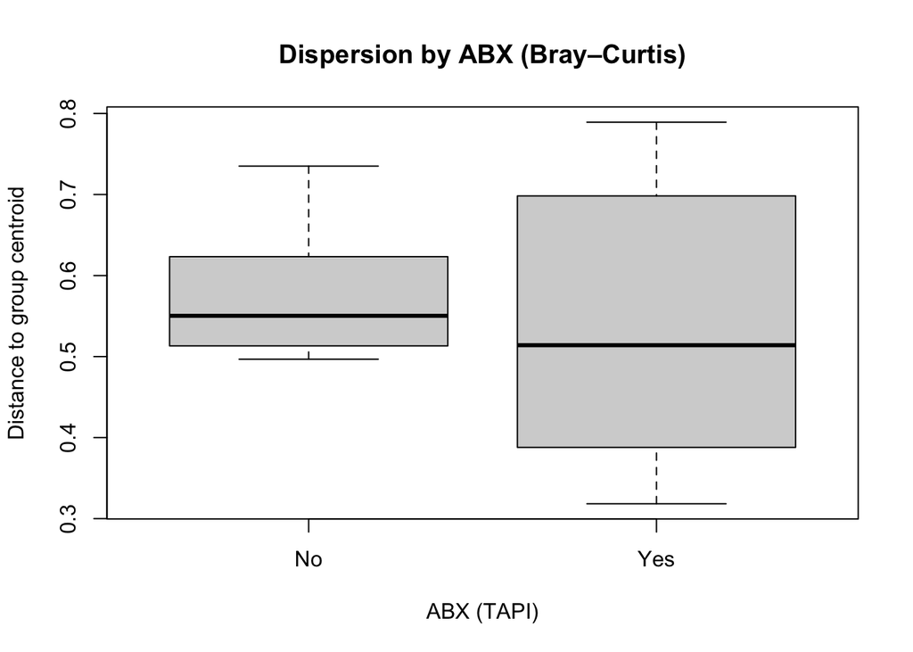

```r
boxplot(
  bd,
  main = "Dispersion by ABX (Bray–Curtis)",
  xlab = "ABX (TAPI)",
  ylab = "Distance to group centroid"
)
```

## Step 4 — Alpha diversity: does ABX change within-sample diversity?

Alpha diversity depends on sequencing depth, so we will rarefy to a common depth for alpha diversity only.

### Step 4A — Choose a rarefaction depth

In this notebook we rarefy to the minimum read depth within our subset to keep all samples.  
In many analyses, you may instead choose a threshold and drop low-depth samples.

```r
min_reads <- min(sample_sums(ps_nocancer_adm))
min_reads
```

```
## [1] 10590
```

### Step 4B — Rarefy (alpha diversity only)

Rarefaction is stochastic. We set a seed to make the workshop results reproducible.

```r
set.seed(1234)

ps_nocancer_adm_rarefied <- rarefy_even_depth(
  ps_nocancer_adm,
  sample.size = min_reads,
  rngseed = 1234,
  replace = FALSE,
  trimOTUs = TRUE,
  verbose = FALSE
)

# After rarefaction, all samples should have the same total reads
summary(sample_sums(ps_nocancer_adm_rarefied))
```

```
##    Min. 1st Qu.  Median    Mean 3rd Qu.    Max.
##   10590   10590   10590   10590   10590   10590
```

### Step 4C — Plot alpha diversity by ABX

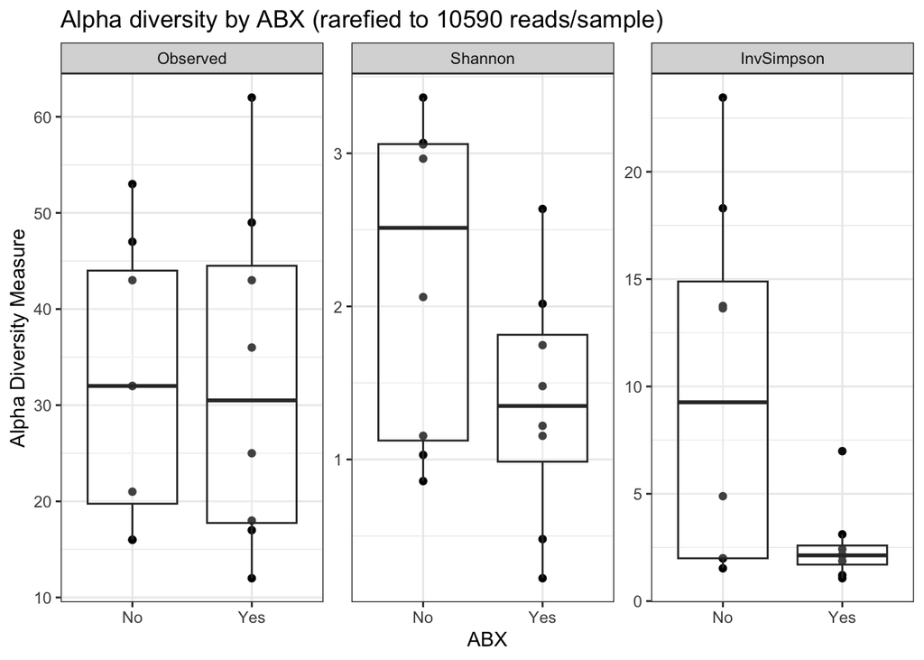

```r
plot_richness(
  ps_nocancer_adm_rarefied,
  x = "ABX",
  measures = c("Observed", "Shannon", "InvSimpson")
) +
  geom_boxplot(aes(group = ABX), alpha = 0.25, outlier.alpha = 0.25) +
  theme_bw() +
  labs(title = paste0("Alpha diversity by ABX (rarefied to ", min_reads, " reads/sample)"))
```

### Step 4D — Statistical tests for alpha diversity

Here we use Wilcoxon rank-sum tests (non-parametric) for each metric.

```r
alpha_tbl <- estimate_richness(
  ps_nocancer_adm_rarefied,
  measures = c("Observed", "Shannon", "InvSimpson")
)

group_vec <- sample_data(ps_nocancer_adm_rarefied)$ABX

# Observed richness
pairwise.wilcox.test(alpha_tbl$Observed, group_vec, alternative = "two.sided")
```

```
##
##  Pairwise comparisons using Wilcoxon rank sum test with continuity correction
##
## data:  alpha_tbl$Observed and group_vec
##
##     No
## Yes 1
##
## P value adjustment method: holm
```

```r
# Shannon
pairwise.wilcox.test(alpha_tbl$Shannon, group_vec, alternative = "two.sided")
```

```
##
##  Pairwise comparisons using Wilcoxon rank sum exact test
##
## data:  alpha_tbl$Shannon and group_vec
##
##     No
## Yes 0.16
##
## P value adjustment method: holm
```

```r
# Inverse Simpson
pairwise.wilcox.test(alpha_tbl$InvSimpson, group_vec, alternative = "two.sided")
```

```
##
##  Pairwise comparisons using Wilcoxon rank sum exact test
##
## data:  alpha_tbl$InvSimpson and group_vec
##
##     No
## Yes 0.13
##
## P value adjustment method: holm
```

## Step 5 — Differential abundance: which taxa differ by ABX?

Community-level tests tell us that samples differ. Differential abundance asks:

**Which taxa are changing between ABX groups?**

Because microbiome data are compositional, we use ALDEx2, which: - performs a CLR transformation, - models sampling uncertainty, - reports both statistical significance and effect size.

### Step 5A — Prepare count matrix for ALDEx2

ALDEx2 expects a taxa x samples count matrix and a group vector.

```r
# Extract counts as a matrix
otu_counts <- as(otu_table(ps_nocancer_adm), "matrix")
if (!taxa_are_rows(ps_nocancer)) {
  otu_counts <- t(otu_counts)
}

# Group vector (ABX status), aligned to columns of otu_counts
group_abx <- as.character(sample_data(ps_nocancer_adm)$ABX)
names(group_abx) <- sample_names(ps_nocancer_adm)

# Ensure alignment
otu_counts <- otu_counts[, names(group_abx), drop = FALSE]
stopifnot(identical(colnames(otu_counts), names(group_abx)))

table(group_abx)
```

```
## group_abx
##  No Yes
##   8   8
```

```r
dim(otu_counts)
```

```
## [1] 304  16
```

### Step 5B — Run ALDEx2 (CLR + tests + effect size)

```r
set.seed(1234)

# CLR transform
x <- ALDEx2::aldex.clr(otu_counts, group_abx)
```

```
## conditions vector supplied
```

```
## operating in serial mode
```

```
## computing center with all features
```

```r
# Wilcoxon rank-sum test (and Welch's t-test also computed)
x_tt <- ALDEx2::aldex.ttest(x, paired.test = FALSE, verbose = FALSE)

# Effect sizes
x_effect <- ALDEx2::aldex.effect(x, CI = TRUE, verbose = FALSE)

# Combine outputs
aldex_out <- data.frame(x_tt, x_effect)

# Filter to significant taxa (raw p-value threshold shown for teaching)
sig_aldex <- aldex_out %>%
  tibble::rownames_to_column(var = "OTU") %>%
  dplyr::filter(wi.ep <= 0.05) %>%
  dplyr::select(OTU, effect, wi.ep, wi.eBH, diff.btw) %>%
  as.data.frame()

nrow(sig_aldex)
```

```
## [1] 1
```

```r
head(sig_aldex)
```

```
##      OTU     effect      wi.ep    wi.eBH  diff.btw
## 1 OTU138 -0.7875493 0.04646343 0.9805002 -4.844917
```

> **Note:** In practice, you will often filter using adjusted p-values (e.g., `wi.eBH`) and interpret effect sizes alongside significance.

### Step 5C — Add taxonomy annotations to significant taxa

```r
tax_tbl <- as.data.frame(tax_table(ps_nocancer_adm), stringsAsFactors = FALSE)

sig_tax <- sig_aldex %>%
  dplyr::left_join(
    tax_tbl %>% tibble::rownames_to_column("OTU"),
    by = "OTU"
  )

head(sig_tax)
```

```
##      OTU     effect      wi.ep    wi.eBH  diff.btw   domain         phylum
## 1 OTU138 -0.7875493 0.04646343 0.9805002 -4.844917 Bacteria Proteobacteria
##                 class             order             family
## 1 Gammaproteobacteria Enterobacteriales Enterobacteriaceae
##                             genus
## 1 unclassified_Enterobacteriaceae
```

## Step 6 — Visualize differential taxa

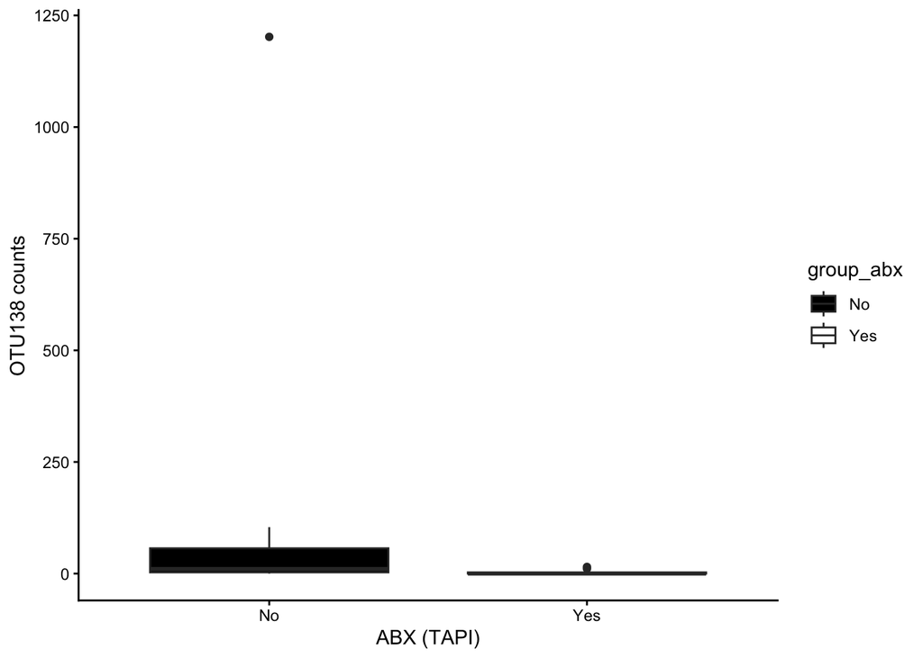

```r
df_nocancer_adm = merge(as.data.frame(group_abx), t(otu_counts), by = "row.names")

OTU138 = ggplot(df_nocancer_adm, aes(x = group_abx, y = OTU138, fill = group_abx)) + labs(x = "ABX (TAPI)", y = "OTU138 counts") +
  geom_boxplot() + theme_classic() + scale_fill_manual(values = c("black", "white"))
OTU138
```

### Step 6A — Effect direction plot (diff.btw)

`diff.btw` is the difference between CLR means (group-wise).

Positive values indicate higher abundance in one group and negative values the other (depending on group coding).

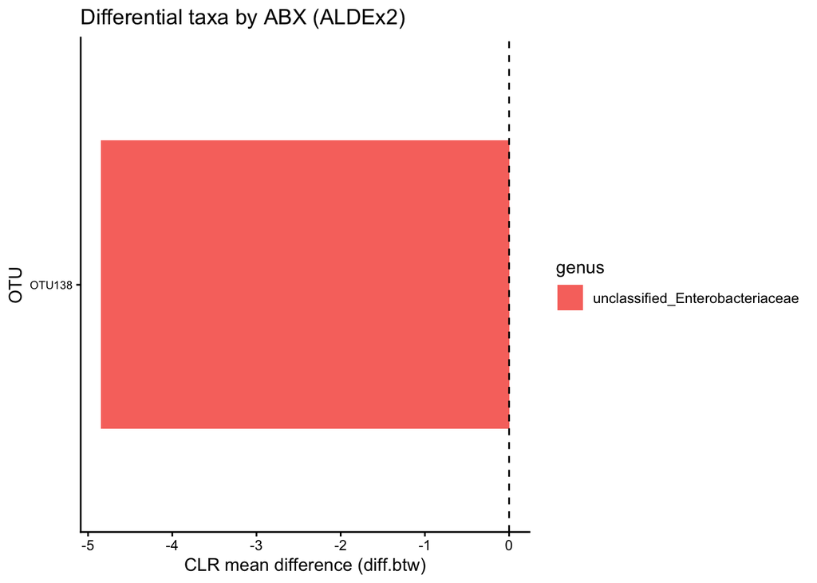

```r
if (nrow(sig_tax) == 0) {
  message("No taxa met the significance threshold (wi.ep <= 0.05). Try a different cutoff or use wi.eBH.")
} else {
  sig_tax$OTU <- factor(sig_tax$OTU, levels = sig_tax$OTU[order(sig_tax$diff.btw)])

  ggplot(sig_tax, aes(x = diff.btw, y = OTU, fill = genus)) +
    geom_col(width = 0.7) +
    geom_vline(xintercept = 0, linetype = "dashed") +
    theme_classic() +
    labs(
      title = "Differential taxa by ABX (ALDEx2)",
      x = "CLR mean difference (diff.btw)",
      y = "OTU"
    ) +
    theme(axis.text.y = element_text(size = 7))
}
```

## Step 7 — Heatmap of differential taxa (relative abundance)

This heatmap shows the relative abundance patterns of significant taxa across samples.

> **Important note:** We use Euclidean distance here only for visualization. This does not replace compositional distance metrics (like Bray–Curtis) used earlier.

### Step 7A — Build relative abundance matrix

```r
# Relative abundance transform (within this subset only)
ps_nocancer_adm_rel <- transform_sample_counts(ps_nocancer_adm, function(x) x / sum(x))

otu_rel <- as(otu_table(ps_nocancer_adm_rel), "matrix")
if (!taxa_are_rows(ps_nocancer_adm_rel)) {
  otu_rel <- t(otu_rel)
}

# Subset to significant taxa (if any)
diff_otus <- sig_aldex$OTU

if (length(diff_otus) == 0) {
  message("No significant taxa to plot in a heatmap (wi.ep <= 0.05).")
} else {
  otu_rel_sig <- otu_rel[rownames(otu_rel) %in% diff_otus, , drop = FALSE]
  dim(otu_rel_sig)
}
```

```
## [1]  1 16
```

### Step 7B — Create heatmap with ABX annotation

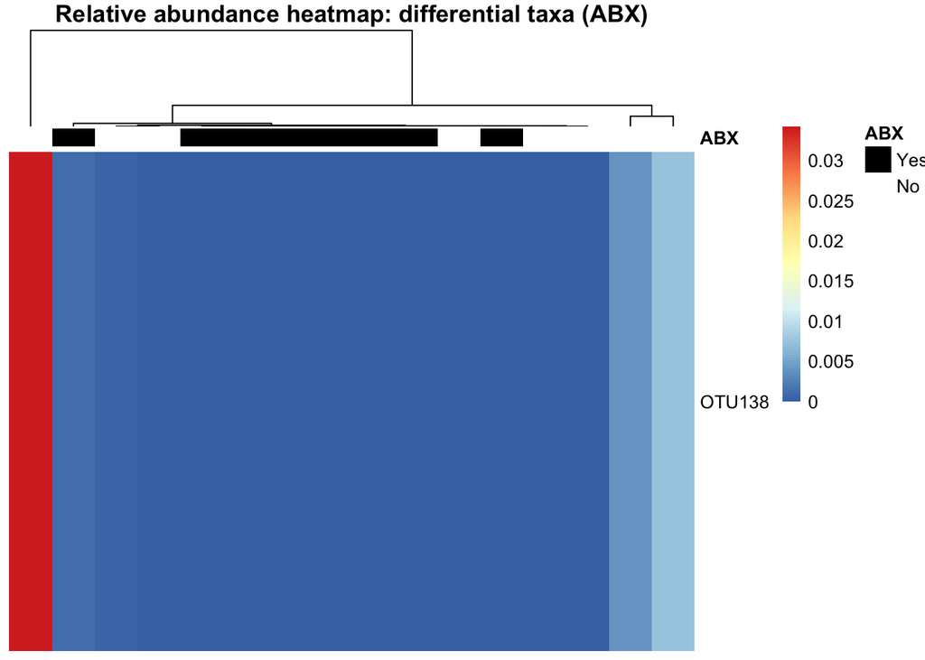

```r
if (length(diff_otus) > 0) {
  hm_meta <- as.data.frame(sample_data(ps_nocancer_adm_rel), check.names = FALSE)
  annotation <- data.frame(ABX = hm_meta$ABX)
  rownames(annotation) <- rownames(hm_meta)

  # Simple ABX color mapping
  abx_cols <- c("Yes" = "black", "No" = "white")
  anno_colors <- list(ABX = abx_cols)

  pheatmap::pheatmap(
    otu_rel_sig,
    cluster_rows = FALSE,
    show_colnames = FALSE,
    clustering_distance_cols = "euclidean",
    border_color = NA,
    annotation_col = annotation,
    annotation_colors = anno_colors,
    main = "Relative abundance heatmap: differential taxa (ABX)"
  )
}
```

# Summary

In this notebook, we:

- Defined a clinically meaningful comparison (ABX vs no ABX in patients without cancer)
- Tested for community-level differences using beta diversity (PCoA + PERMANOVA)
- Checked dispersion (betadisper) to interpret PERMANOVA results appropriately
- Evaluated within-sample diversity using rarefied alpha diversity metrics
- Identified candidate taxa associated with ABX using ALDEx2 (CLR + effect sizes)
- Visualized differential taxa using effect-direction plots and a relative abundance heatmap

Together, these steps demonstrate how microbiome data can be .linked to metadata to generate biologically and clinically interpretable hypotheses. This concludes our workshop. We hope you have found th workshop informative and useful.